# Practical Machine Learning Course Project

Alessandro Capuani

21/04/2015

```r
library(caret)
data_r <- read.table('pml-training.csv',header=T,row.names=1,sep=",")
```

The variables “user_name”,“raw_timestamp_part_1”,“raw_timestamp_part_2” and “cvtd_timestamp” were also removed, since they do not have any influence on the response variable “classe”, as shown below.

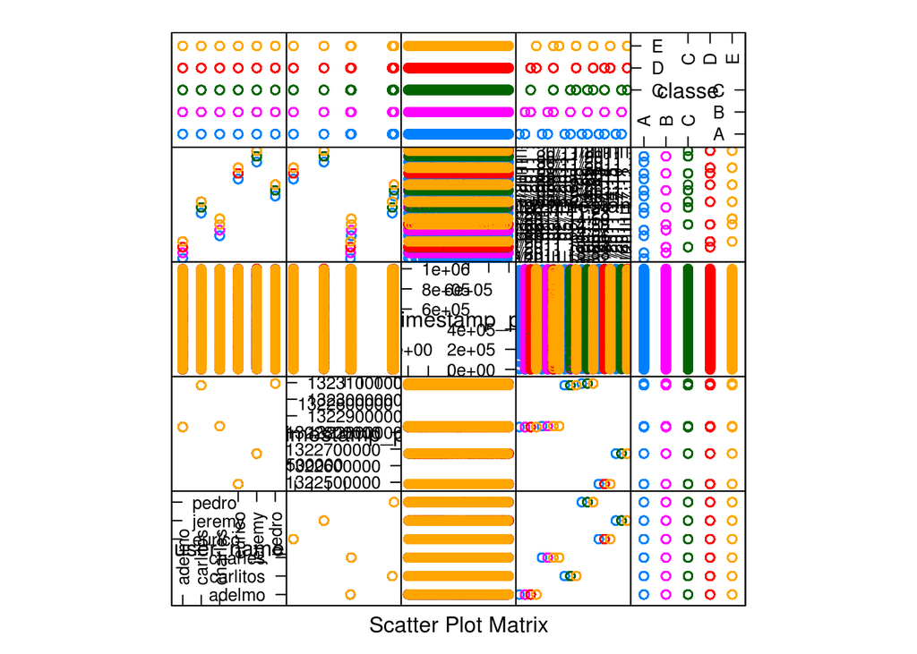

```r
featurePlot(x=data_r[,c("user_name","raw_timestamp_part_1",
                       "raw_timestamp_part_2",
                       "cvtd_timestamp","classe")],y=data_r$classe,
                        plot="pairs")
```

The function nearZeroVar from the caret package was used to detect variables with zero or near zero variance. Finally, after pre-processing 53 predictors were retained for train and test data sets, without considering the response variable.

```r
data_filtered <- data_r[,colSums(is.na(data_r)) == 0]
nzv <- nearZeroVar(data_filtered, saveMetrics= FALSE)
data_filtered <- data_filtered[,-nzv]
data_filtered <- data_filtered[,-c(1:4)]

test <- read.table('pml-testing.csv',header=T,row.names=1,sep=",")
test_filtered <-test[,colnames(data_filtered[,1:53])]
dim(data_filtered)
```

```
## [1] 19622    54
```

```r
dim(test_filtered)
```

```
## [1] 20 53
```

The train data set was splitted in two parts, training and validation data sets. The latest will be used to validate our model.

```r
trainIndex <- createDataPartition(data_filtered$classe, p = .8,
                                  list = FALSE,
                                  times = 1)

training <-data_filtered[trainIndex,]
validation <-data_filtered[-trainIndex,]
```

Random forest was use as model due to its high accuracy. A cross validation with 3 folds was applied as resampling method. A seed was set because of the randomization reproducibility. The trained model showed a very high accuracy, as also displayed in the output below.

```r
set.seed(3254)
fitControl <- trainControl(## 3-fold CV
                           method = "cv",
                           number = 3,
                           ## repeated ten times
                           repeats = 3,
                           verboseIter = FALSE)

modelFit_RF <-train(classe ~.,data=training,method="rf",trControl = fitControl,verbose=T)
modelFit_RF
```

```
## Random Forest
##
## 15699 samples
##    53 predictors
##     5 classes: 'A', 'B', 'C', 'D', 'E'
##
## No pre-processing
## Resampling: Cross-Validated (3 fold)
##
## Summary of sample sizes: 10468, 10465, 10465
##
## Resampling results across tuning parameters:
##
##   mtry  Accuracy   Kappa      Accuracy SD   Kappa SD
##    2    0.9928019  0.9908948  0.0008637428  0.0010931686
##   27    0.9966239  0.9957294  0.0004818364  0.0006095255
##   53    0.9933113  0.9915388  0.0020155575  0.0025492775
##
## Accuracy was used to select the optimal model using  the largest value.
## The final value used for the model was mtry = 27.
```

Moreover, also using the validation set, it is possible to see that the error within the categories very low is.

```r
pred <-predict(modelFit_RF,validation[,1:53])
known <-validation$classe
table(pred,known)
```

```
##     known
## pred    A    B    C    D    E
##    A 1115    1    0    0    0
##    B    1  758    1    0    0
##    C    0    0  683    2    0
##    D    0    0    0  641    0
##    E    0    0    0    0  721
```

Thanks to wugulino at inf dot puc-rio dot br to share their data set-